# Exercise for Lecture 5 - Differential expression with the limma package

Holub Martin

21 10 2017

The purpose of this exercise is to simulate some “microarray” data and explore how well different statistical tests separate truly differential expression (in a small sample situation). This will introduce you to: i) simulation; ii) metrics to assess statistical performance; iii) some variations of the t-test.

Specifically, we will create a synthetic dataset with replicates from 2 experimental conditions and put in differential expression for some features. The goal is to see how well different statistical summaries can distinguish between those “truly” differential and those not differential.

Below is some R code to get you started.

```r
library("limma")
```

Next, we set some parameters for the simulation. You will modify these to explore a few situations.

```r
nGenes <- 10000                   # number of "features"
nSamples <- 6                     # number of samples (split equal in 2 groups)
pDiff <- .1                       # percent of genes "differential
grp <- rep(0:1,each=nSamples/2)   # dummy variable for exp. group
trueFC <- 2                       # log-fold-change of truly DE

d0 <- 1
s0 <- 0.8
sd <- s0*sqrt(d0/rchisq(nGenes,df=d0))  # dist'n of s.d.
```

Note: there are some details regarding the scaled inverse chi-square distribution that you may want to explore. For example, see the [wiki description](http://en.wikipedia.org/wiki/Scaled_inverse_chi-square_distribution).

#### Question 1. Look at the distribution of “true” s.d. (each gene has a different s.d.). You will change this distribution later to see effect on differential detection performance.

#### Answer 1.

We look at the distribution and see that it allows for very high values of standard deviation (max: 7906.164032, min: 0.1805917), this is because chi-squared has support on (0, +). We can also find out that chi-squared is a special case of exponential distribution and thus we will prefer to look at histogram of log-transformed values. We see that the values are centered around zero which also makes sense. There is 0 values that are exactly 0. And 10000 or 0 values that are greater or lower than zero.

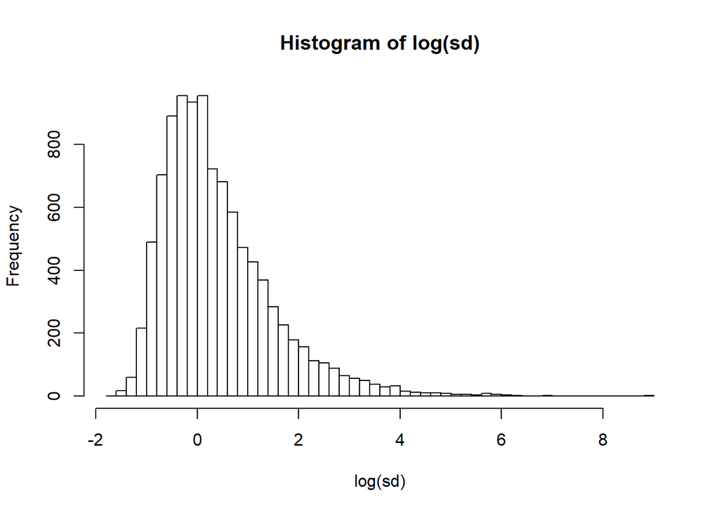

```r
#hist(sd[sd < (0.9*max(sd))], breaks = 20)
hist(log(sd), breaks = 50)
```

Next, we can generate a table of (null) data:

```r
y <- matrix(rnorm(nGenes*nSamples,sd=sd),
            nr=nGenes,nc=nSamples)
```

And, we can add in “differential expression”, randomly chosen to be in the positive or negative direction, to a set of indices chosen:

```r
indD <- 1:floor(pDiff*nGenes)
diff <- sample(c(-1,1),max(indD),replace=TRUE)*trueFC
y[indD,grp==1] <- y[indD,grp==1] + diff
```

We note that y matrix holds log2 expression values and that fold change becomes and additive operation in log space. Also, the distribution of the values in y matrix is identical for both groups and we can thus assume equal variances.

#### Question 2. To make sure you understand the simulation, look at some of the rows in the table. For example, plot the data (e.g., a barplot) for a few rows that are truly differential and a few rows that are non-differential.

#### Answer 2.

We have a table in variable `y` that has 10^{4} rows and 6 columns. It’s values range from 9609.986876 to -2.105973810^{4}. We will decide whether expression of given gene is differnetial among the two samples using two sided t-test on each row. We adopt 0.01 or 0.05 as a threshold level of significance for p-value.

```r
down_tf <- rep(FALSE, nrow(y))
up_tf <- rep(FALSE, nrow(y))
twosided_tf <- rep(FALSE, nrow(y))

for (row in 1: nrow(y)){ # do it only where differential expression expected
#for (row in 1: length(indD)){
  x0 <- y[row, grp == 0]
  x1 <- y[row, grp == 1]
  res_up <- t.test(x0, x1, alternative = "greater", var.equal = TRUE)$p.value
  res_down <- t.test(x0, x1, alternative = "less", var.equal = TRUE)$p.value
  res_twosided <- t.test(x0, x1, alternative = "two.sided", var.equal = TRUE)$p.value

  if (res_down < .05){
    down_tf[row] <- TRUE
  }
  if (res_up < .05){
    up_tf[row] <- TRUE
  }
  if (res_twosided < .05){
    twosided_tf[row] <- TRUE
  }
}
```

```r
upregulated <- y[up_tf, ]
downregulated <- y[down_tf, ]
differential <- y[twosided_tf, ]
nondifferential <- y[! twosided_tf[indD], ]
```

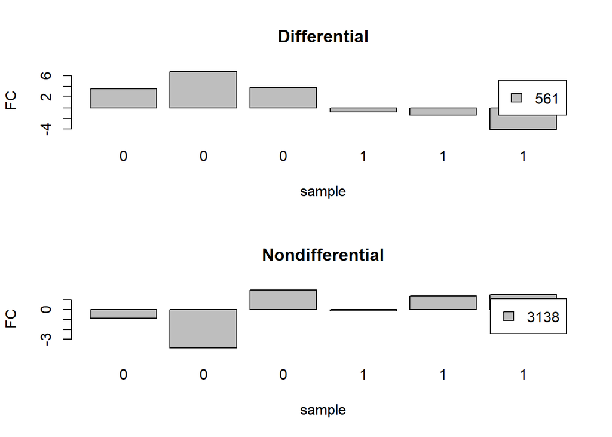

```r
# Note for myself: https://plot.ly/r/parallel-coordinates-plot/

gene_ids <- sample(nrow(differential), 1)
diff_sample <- differential[gene_ids, ]
par(mfrow = c(2, 1))
barplot(diff_sample, ylab = "FC", xlab = "sample", axes = TRUE, legend.text = gene_ids, names.arg = grp, main = "Differential")


gene_ids <- sample(nrow(nondifferential), 1)
nondiff_sample <- nondifferential[gene_ids, ]
barplot(nondiff_sample, ylab = "FC", xlab = "sample", axes = TRUE, legend.text = gene_ids, names.arg = grp, main = "Nondifferential")
```

Next, we create a design matrix to feed into limma:

```r
design <- model.matrix(~grp)
```

#### Question 3. What is the interpretation of the two columns of this design matrix?

#### Answer 3.

Column 1 in this design matrix corresponds to *group0* and Column 2 represents *group1*.

We are looking for giving best fit in $y = X\cdot\alpha + \epsilon$, where $X$ is the design matrix, $\alpha$ is vector of coefficients, $y$ is the observed expression, and $\epsilon$ is vector representing additive noise.

The design matrix is constructed such that $\alpha_1$ will correspond to *group0* and $\alpha_2$ to *group1* - *group0*.

**Q: What is interpretation of Intercept??**

Below is a standard limma pipeline. We will unravel many details of these steps in the coming weeks.

```r
fit <- limma::lmFit(y,design)
fit <- limma::eBayes(fit, robust = TRUE)
```

#### Question 4. For each row in the simulated table, calculate the classical 2-sample t-test (perhaps store the result in a vector named ‘classicalt’; see below). See ?t.test for more details about the built-in R function to do this calculation and convince yourself which arguments to use to match the t-test described in class.

#### Answer 4.

We adopt the same approach as for Answer 2. and we loop over all rows. We recall that groups come originally from same distribution and addition of `diff` factor didn’t change the variance, therefore we assume variances equal between samples

```r
classicalt <- vector(mode = "numeric", length = nrow(y))
classicalt_res <- list()
data <- list()
for (row in 1: nrow(y)){
  x0 <- y[row, grp == 0]
  x1 <- y[row, grp == 1]
  classicalt[row] <- t.test(x0, x1, alternative = "two.sided", var.equal = TRUE)$statistic
  classicalt_res <- append(classicalt_res, list(t.test(x0, x1, alternative = "two.sided", var.equal = TRUE)))
}
```

Below, a vector of colours is made to signify the true differential “status”, which will be used in exploratory plots:

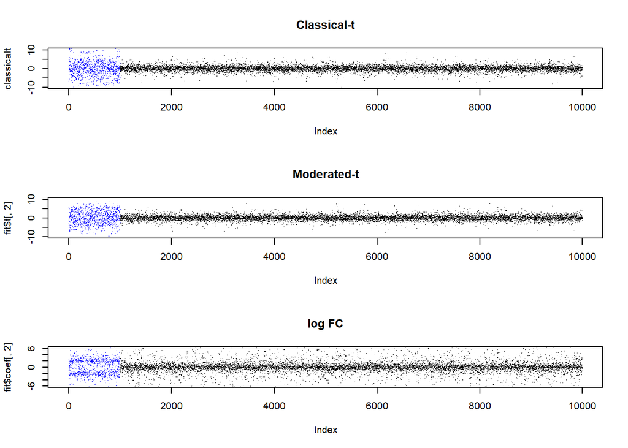

```r
cols <- rep("black",nrow(y))
cols[indD] <- "blue"

par(mfrow=c(3,1))
plot( classicalt, col=cols, ylim=c(-10,10), pch=".", main="Classical-t" )
plot( fit$t[,2], col=cols, ylim=c(-10,10), pch=".", main="Moderated-t" )
plot( fit$coef[,2], col=cols, ylim=c(-6,6), pch=".", main="log FC" )
```

#### Question 5. Add an exploratory visualization to your plots above, perhaps with a command similar to below. From this visualization, summarize any differences you see between the three statistical summaries of a change between experimental groups.

We can see multiple things:

- First 1000 genes clearly show different distribution pattern of fold-change values. This is expected as we fabricated it.
- Correspondingly, t-statistics reach higher absolute vaules for these genes and can lead to rejection of null hypothesis if the observed difference in expression pattern is above some significance threshold.
- Moderate t-statistic appears to be more closely packed around 0, which is in-line with what we would expect as it is regularized by pull to mean value which is in turn governed by majority of ‘genes’ which expression wasn’t manipulated and thus are unlikely to show differential expression. We confirm this visually by plotting density estimate.

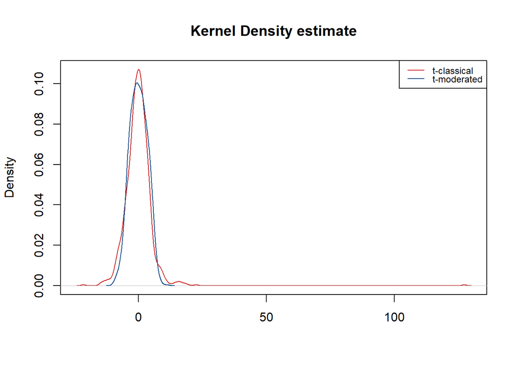

```r
d1 <- density(classicalt[indD], bw ="SJ", kernel= "gauss", na.rm = TRUE)
d2 <- density(fit$t[indD,2], bw ="SJ", kernel= "gauss", na.rm = TRUE)
colors_t = c("firebrick3", "dodgerblue4")

#h1 <- hist(classicalt[indD], breaks = 20)
#h2 <- hist(fit$t[indD,2], breaks = 20)
#plot( h1, col=colors_t[1], xlim=c(-10,10), main = "Hist of t and t-moderated")
#plot( h2, col=colors_t[2], xlim=c(-10,10), add=T)

plot( d1, col=colors_t[1], xlab = "", main = "Kernel Density estimate")
lines( d2, col=colors_t[2], xlab = "")

legend("topright", legend = c("t-classical", "t-moderated"), col = colors_t, lwd = 1, cex = 0.75,y.intersp = 0.75, ncol = 1)
```

#### Question 6. Pick a reasonable metric to compare the methods: ROC curve, false discovery plot, power versus achieved FDR. Using this metric/curve, compare the classical t-test (classicalt), the moderated t-test (fit$t) and the log-fold-change or mean difference (fit$coef). Either manually calculate and plot it or use a nice package for it (e.g., https://rocr.bioinf.mpi-sb.mpg.de/ or https://github.com/markrobinsonuzh/benchmarkR) What method(s) perform well?

**Q:How to pick decision threshold for log2-fold-change to obtain at least similar performance as with the t-test methods? Is there more eleganr way how to evaluate the peroframance?**

#### Answer 6.

```r
p_vals_class <- unlist(lapply(classicalt_res, function (x) x$p.value[[1]]))
p_vals_mod <- fit$p.value[, 2] # why second column?
fc_vals <- abs(fit$coef[, 1] - fit$coef[, 2])
ground_truth <- rep(0, nrow(y))
ground_truth[1:max(indD)] <- rep(1, max(indD))
colors_roc = c("firebrick3", "dodgerblue4", "forestgreen")
```

```r
library(ROCR)
```

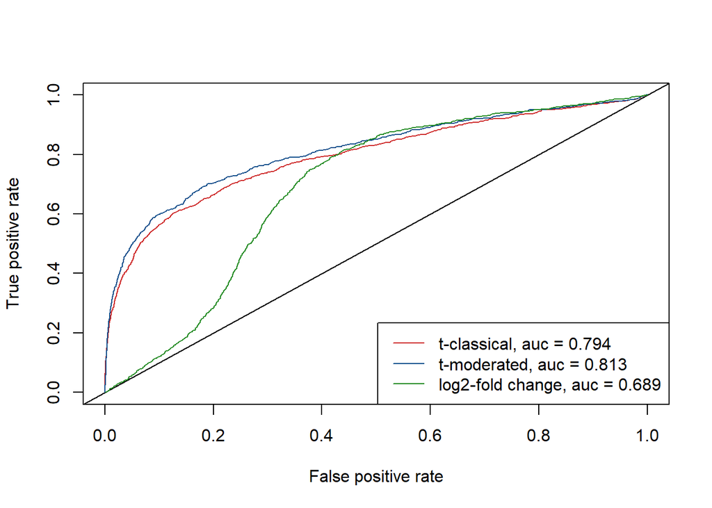

```r
samp_sizes <- seq(2*max(indD), nrow(y), by = 2*length(indD))
perf_class_container <- list()
perf_mod_container <- list()

for (it in 5){
  idxer <- rep(FALSE, nrow(y))
  samp_size <- samp_sizes[it]
  idxer[1: samp_size] <- rep(TRUE, samp_size)

  pred_class <- prediction(1 - p_vals_class[idxer], ground_truth[idxer])
  pred_mod <- prediction(1 - p_vals_mod[idxer], ground_truth[idxer])
  pred_fc <- prediction(fc_vals[idxer], ground_truth[idxer]*trueFC)

  perfc <- performance(pred_class, measure = "tpr", x.measure = "fpr")
  aucc <- performance(pred_class, measure = "auc")
  perfm <- performance(pred_mod, measure = "tpr", x.measure = "fpr")
  aucm <- performance(pred_mod, measure = "auc")
  perffc <-performance(pred_fc, measure = "tpr", x.measure = "fpr")
  aucfc <- performance(pred_fc, measure = "auc")

  #perfc <- sum((p_vals_class[idxer] > thresh)) / samp_size # TP
  #perfm <- sum((p_vals_mod[idxer] > thresh)) / samp_size # TP

  #perf_class_container <- append(perf_class_container, perfc)
  #perf_mod_container <- append(perf_mod_container, perfm)

  plot(perfc, col = colors_roc[1])
  abline(a=0, b= 1)
  plot(perfm, add = TRUE, col = colors_roc[2])
  plot(perffc, add = TRUE, col = colors_roc[3])

  leg1 <- sprintf("t-classical, auc = %1.3f", round(unlist(aucc@y.values), 3))
  leg2 <- sprintf("t-moderated, auc = %1.3f", round(unlist(aucm@y.values), 3))
  leg3 <- sprintf("log2-fold change, auc = %1.3f", round(unlist(aucfc@y.values), 3))
  legend("bottomright", legend = c(leg1, leg2, leg3), col = colors_roc, lwd = 1, cex = 1,y.intersp = 1, ncol = 1)
}
```

```r
#plot(samp_sizes[1:it], ylim = c(0.9, 1.1), perf_class_container, col = "red")
#points(samp_sizes[1:it], perf_mod_container, col = "blue")
```

Next we could for example plot similar plots as show in the “LIMMA” paper (# of genes selected vs. # of false discoveries). In outter loop we would draw samples of increasing size and in the inner loop we would sample multiple times to get good statistics. False discovery would be defined as `p.value < 0.05` for a gene from `y_prime` where `y_prime` corresponds to all genes which expression wasn’t manipulated.

#### Question 7. Explore the performance of these test statistics for a few scenarios. For example, change the sample size, the number of genes DE, magnitude of the difference, level of variability. What influence do these parameters have on the relative performance?

#### Answer 7.

Increasing power of the t-test (more samples, higher logFC, lower variability) leads to performance of classical t-test approaching that of a moderated t-test.

#### Note: Submit both an Rmarkdown/markdown file as well as a compiled HTML file to your private github repository.